# Course Project Description

Luoping Qu 919618059

March 18th 2024

## Abstract

As a collection project of STA141A, this document is a report analysis derived from the exploration of a large set of data in neural activity for mice, and able to use the information and context of trials to form a predictive model. The goal is to predict models that allow us to forecast the outcome of different trials using different variables within the given dataset. After deciding on the final model, the student will be assigned to a new dataset to test the model’s performance.

# Background

In this project, we will be assigned to analyze a dataset that was collected from Steinmetz, N.A., Zatka-Haas, P., Carandini, M. et al. Distributed coding of choice, action and engagement across the mouse brain. Nature 576, 266–273 (2019).. In this study, the original set of data consists of 39 sessions worth of hundreds of experimental trials that were performed on 10 different mice. And the dataset we will be using will be performed on a total of 4 mice over 18 sessions, which these sessions rds also consisted of hundreds of trials. In the trials, these mice were randomly presented with visual stimuli on two different sides on either side of the mouse. These visual that were shown to each mouse will be present randomly in contrast levels that were labeled as (0, 0.25, 0.5, 1), where 0 means no stimuli. The mice will use a wheel controlled by their forepaws to make decisions regarding the provided stimuli. Depending on the decision made by the mouse, a reward or penalty was administered. Bases on the outcome of their decisions, they will be relatively given reward or penalty.

For our project, we will use data from 18 experimental sessions involving four mice named Cori, Forssmann, Hench, and Lederberg. We’re analyzing the spike train data that represents the neuronal activity in the visual cortex of these mice, specifically capturing the neural firing from the stimulus onset to 0.4 seconds afterward.

## # Section 1 Introduction

A total of 18 RDS files are provided that contain the records from 18 sessions. In each RDS file, you can find the name of mouse from `mouse_name` and date of the experiment from `date_exp`.

Each variables contains in a session

```
## [1] "contrast_left"  "contrast_right" "feedback_type"  "mouse_name"
## [5] "brain_area"     "date_exp"       "spks"           "time"
```

Session contains 8 variables: “contrast_left”, “contrast_right”, “feedback_type”, “mouse_name”, “brain_area”, “date_exp”, “spks”, “time”

What’s in a trail?

```
## [1] 734  40
```

```
## [1] 734
```

```
##  [1] 0 1 0 1 0 0 0 0 0 0 0 0 0 0 0 0 0 0 0 0 1 1 0 0 0 0 1 0 0 0 0 0 1 0 0 1 0 0
## [39] 0 0
```

Connect the neuron spike with brain area

```
## [1] 1
```

```
##
##  ACA  CA3   DG   LS  MOs root  SUB VISp
##  109   68   34  139  113   18   75  178
```

```
## [1] 216
```

Imports all the packages

[output not shown]

[output not shown]

[output not shown]

[output not shown]

[output not shown]

### Data processing

```r
trail_tibble_1_114 <- get_trail_data(1,114)
trail_tibble_1_114
```

```
## # A tibble: 8 × 8
##   brain_area sum_spks region_count mean_spks n.trail contrast_right
##   <chr>         <dbl>        <int>     <dbl>   <dbl>          <dbl>
## 1 ACA              99          109     0.908     114              1
## 2 CA3             105           68     1.54      114              1
## 3 DG               58           34     1.71      114              1
## 4 LS              169          139     1.22      114              1
## 5 MOs              75          113     0.664     114              1
## 6 SUB             143           75     1.91      114              1
## 7 VISp            282          178     1.58      114              1
## 8 root             18           18     1         114              1
## # ℹ 2 more variables: contrast_left <dbl>, feedback_type <dbl>
```

```r
#
session_13 <- get_session_data(13)
session_13
```

```
## # A tibble: 4,500 × 11
##    brain_area sum_spks region_count mean_spks n.trail contrast_right
##    <chr>         <dbl>        <int>     <dbl>   <int>          <dbl>
##  1 ACA              50           58     0.862       1              0
##  2 CA1              21           34     0.618       1              0
##  3 DG               29           17     1.71        1              0
##  4 LGd             161          150     1.07        1              0
##  5 MB              280           63     4.44        1              0
##  6 MOs              49           46     1.07        1              0
##  7 MRN             276           51     5.41        1              0
##  8 MS               97           23     4.22        1              0
##  9 PL              278          184     1.51        1              0
## 10 RN              480           58     8.28        1              0
## # ℹ 4,490 more rows
## # ℹ 5 more variables: contrast_left <dbl>, feedback_type <dbl>,
## #   n.session <dbl>, mouse_name <chr>, date_exp <chr>
```

```
## # A tibble: 6 × 13
##   brain_area sum_spks region_count mean_spks n.trail contrast_right
##   <chr>         <dbl>        <int>     <dbl>   <int>          <dbl>
## 1 ACA             138          109     1.27        1            0.5
## 2 CA3             104           68     1.53        1            0.5
## 3 DG               79           34     2.32        1            0.5
## 4 LS              269          139     1.94        1            0.5
## 5 MOs             106          113     0.938       1            0.5
## 6 SUB             156           75     2.08        1            0.5
## # ℹ 7 more variables: contrast_left <dbl>, feedback_type <dbl>,
## #   n.session <int>, mouse_name <chr>, date_exp <chr>, success <dbl>,
## #   contrast_different <dbl>
```

# Section 2 Exploratory analysis (EDA)

###Overall summary

```
##     sum_spks       region_count      mean_spks       contrast_right
##  Min.   :   0.0   Min.   :  3.00   Min.   : 0.0000   Min.   :0.0000
##  1st Qu.:  41.0   1st Qu.: 36.00   1st Qu.: 0.8082   1st Qu.:0.0000
##  Median :  85.0   Median : 67.00   Median : 1.2121   Median :0.2500
##  Mean   : 124.7   Mean   : 94.01   Mean   : 1.5142   Mean   :0.3209
##  3rd Qu.: 162.0   3rd Qu.:122.00   3rd Qu.: 1.8081   3rd Qu.:0.5000
##  Max.   :1274.0   Max.   :628.00   Max.   :14.6667   Max.   :1.0000
##  contrast_left    feedback_type       n.session         n.trail
##  Min.   :0.0000   Min.   :-1.0000   Min.   : 1.000   Min.   :  1.0
##  1st Qu.:0.0000   1st Qu.:-1.0000   1st Qu.: 7.000   1st Qu.: 72.0
##  Median :0.2500   Median : 1.0000   Median :10.000   Median :146.0
##  Mean   :0.3467   Mean   : 0.4089   Mean   : 9.972   Mean   :154.5
##  3rd Qu.:0.5000   3rd Qu.: 1.0000   3rd Qu.:13.000   3rd Qu.:221.0
##  Max.   :1.0000   Max.   : 1.0000   Max.   :18.000   Max.   :447.0
##  contrast_different
##  Min.   :0.0000
##  1st Qu.:0.0000
##  Median :0.5000
##  Mean   :0.4271
##  3rd Qu.:0.7500
##  Max.   :1.0000
```

```
##
##   ACA   ACB   AUD   BLA   CA1   CA3    CP    DG   EPd   GPe   ILA    LD   LGd
##  1257   216   290   404  3249  1888   810  2182   252   851   250  1098  1789
##    LH    LP    LS   LSc   LSr    MB    MD   MEA    MG   MOp   MOs   MRN    MS
##   340   478   114   342  1213  1431   340   224   228   342  1775  1243   300
##    NB   OLF   ORB  ORBm    OT   PAG   PIR    PL    PO   POL  POST    PT    RN
##   228   254   522   372   216   268   252  1516   250   447   926   342   300
##  root   RSP    RT   SCm   SCs  SCsg    SI   SNr   SPF   SSp   SSs   SUB    TH
##  4552   268   224  1015   568   447   216   216   228   822   280  1207  1407
##    TT  VISa VISam  VISl  VISp VISpm VISrl   VPL   VPM    ZI
##   622   753  1240  1070  1896   251   447  1097   628   920
```

### Checking Missing Value

```
## [1] 0
```

```
##         brain_area           sum_spks       region_count          mean_spks
##                  0                  0                  0                  0
##            n.trail     contrast_right      contrast_left      feedback_type
##                  0                  0                  0                  0
##          n.session         mouse_name           date_exp            success
##                  0                  0                  0                  0
## contrast_different
##                  0
```

```
##                       sum_spks region_count    mean_spks contrast_right
## sum_spks            1.00000000  0.764643357  0.315009313   6.028187e-02
## region_count        0.76464336  1.000000000 -0.157243826   4.369128e-03
## mean_spks           0.31500931 -0.157243826  1.000000000   7.195470e-02
## contrast_right      0.06028187  0.004369128  0.071954705   1.000000e+00
## contrast_left       0.01534199 -0.000959457  0.007723305  -5.503218e-02
## feedback_type       0.04021741 -0.001082795  0.068429165  -4.776491e-05
## n.session          -0.08149257 -0.144872115  0.068219265  -3.230904e-02
## n.trail            -0.05295573 -0.025310547 -0.047356091   1.475310e-02
## contrast_different  0.04285006 -0.014146719  0.061252488   4.307998e-01
##                    contrast_left feedback_type   n.session     n.trail
## sum_spks             0.015341995  4.021741e-02 -0.08149257 -0.05295573
## region_count        -0.000959457 -1.082795e-03 -0.14487212 -0.02531055
## mean_spks            0.007723305  6.842917e-02  0.06821927 -0.04735609
## contrast_right      -0.055032179 -4.776491e-05 -0.03230904  0.01475310
## contrast_left        1.000000000  4.111260e-02  0.01337751  0.07999273
## feedback_type        0.041112599  1.000000e+00  0.09750510 -0.12160078
## n.session            0.013377510  9.750510e-02  1.00000000  0.10490417
## n.trail              0.079992730 -1.216008e-01  0.10490417  1.00000000
## contrast_different   0.467955015  1.407771e-01  0.01371211  0.10625042
##                    contrast_different
## sum_spks                   0.04285006
## region_count              -0.01414672
## mean_spks                  0.06125249
## contrast_right             0.43079977
## contrast_left              0.46795501
## feedback_type              0.14077712
## n.session                  0.01371211
## n.trail                    0.10625042
## contrast_different         1.00000000
```

## Explore the neural activities during each trial, what is going on within each session and mouse?

### Number of brain area in each session

```
##    n.session region_count
## 1          1          734
## 2          2         1070
## 3          3          619
## 4          4         1769
## 5          5         1077
## 6          6         1169
## 7          7          584
## 8          8         1157
## 9          9          788
## 10        10         1172
## 11        11          857
## 12        12          698
## 13        13          983
## 14        14          756
## 15        15          743
## 16        16          474
## 17        17          565
## 18        18         1090
```

### Numbers of brain area of each session

```
##    n.session unique_area
## 1          1           8
## 2          2           5
## 3          3          11
## 4          4          11
## 5          5          10
## 6          6           5
## 7          7           8
## 8          8          15
## 9          9          12
## 10        10          13
## 11        11           6
## 12        12          12
## 13        13          15
## 14        14          10
## 15        15           8
## 16        16           6
## 17        17           6
## 18        18          10
```

### Average spike rate over each session

```
##    n.session mean_session_spks
## 1          1         1.5396410
## 2          2         1.2656328
## 3          3         2.2339370
## 4          4         0.8415550
## 5          5         1.1158292
## 6          6         0.6631899
## 7          7         1.4153756
## 8          8         1.6555678
## 9          9         1.5873690
## 10        10         1.1875358
## 11        11         1.2504896
## 12        12         1.6632648
## 13        13         2.4576806
## 14        14         1.0066088
## 15        15         1.4640839
## 16        16         1.0503767
## 17        17         1.1658107
## 18        18         1.0964407
```

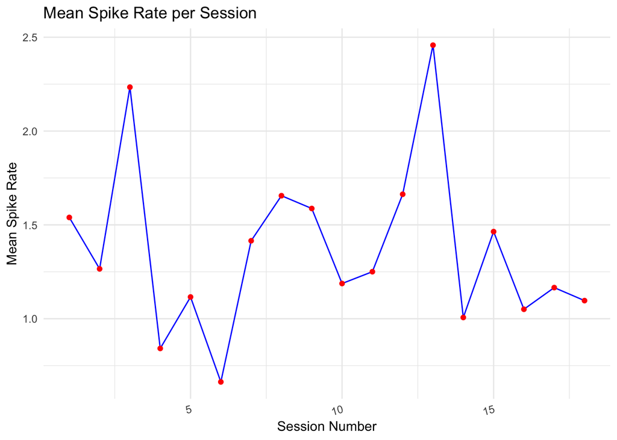

From the above graph, we can see that session 3 and 13 have the relatively higher mean spike rate than other sessions, which suggesting a potential increase in neural activity or a response to stimuli during these two sessions.

### Average spike rate over mouse

```
##   mouse_name mean_mouse_spks
## 1       Cori       1.5724965
## 2  Forssmann       0.8924902
## 3      Hench       1.3359053
## 4  Lederberg       1.4860028
```

[figure not shown]

This bar plot shows the average spike rate recorded across sessions for four different mice: Cori, Forssmann, Hench, and Lederberg. Cori shows the highest average spike rate, while Forssmann were the lowest. Hench and Lederberg have moderate closer rates, with Lederberg slightly higher than Hench. This visualization suggests variability in neural activity among the mice, which could be due to individual adapatability or experimental conditions.

### The brain areas recorded in each session

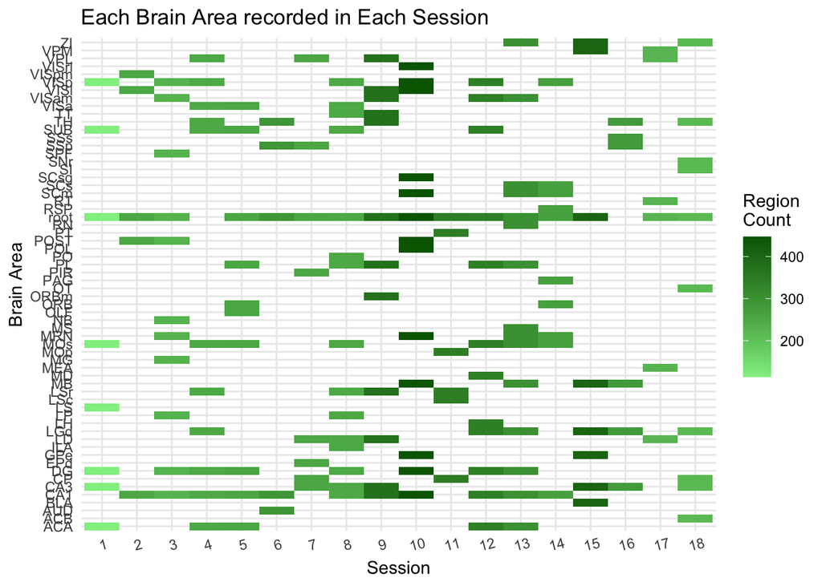

### Estimate success rate over each session

```
##    n.session success_rate_session
## 1          1            0.6052632
## 2          2            0.6334661
## 3          3            0.6622807
## 4          4            0.6666667
## 5          5            0.6614173
## 6          6            0.7413793
## 7          7            0.6706349
## 8          8            0.6440000
## 9          9            0.6854839
## 10        10            0.6196868
## 11        11            0.7953216
## 12        12            0.7382353
## 13        13            0.7966667
## 14        14            0.6940299
## 15        15            0.7648515
## 16        16            0.7178571
## 17        17            0.8303571
## 18        18            0.8055556
```

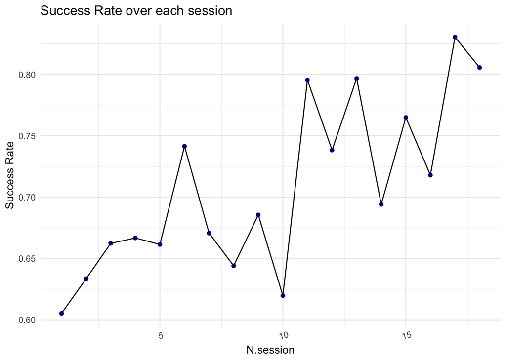

### Estimate success rate over each mouse name

```
##   mouse_name success_rate_mouse
## 1       Cori          0.6434225
## 2  Forssmann          0.6784448
## 3      Hench          0.6660447
## 4  Lederberg          0.7618927
```

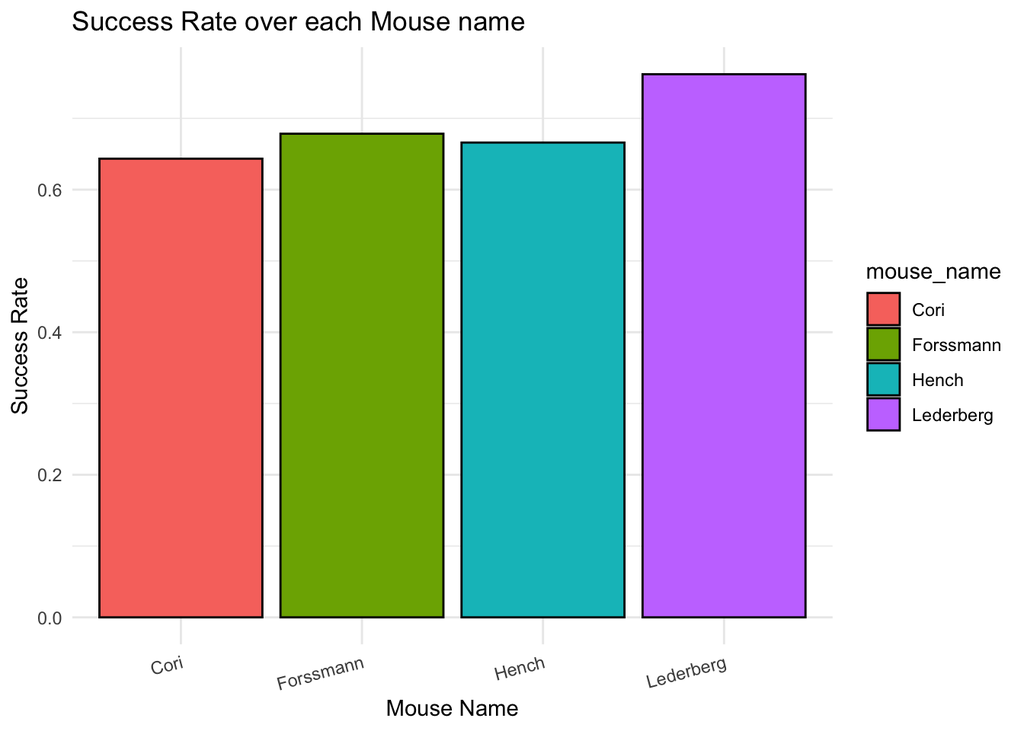

### Distribution for contrast different.

```
##   contrast_diff count   percent
## 2          0.25  6885 0.1400159
## 4          0.75  7162 0.1456490
## 5             1  8868 0.1803429
## 3           0.5 10082 0.2050312
## 1             0 16176 0.3289610
```

### Contrast difference affect on the success rate

```
##   contrast_different cont_diff_success_rate
## 1               0.00              0.6196835
## 2               0.25              0.6624546
## 3               0.50              0.7724658
## 4               0.75              0.7401564
## 5               1.00              0.7855210
```

### Does the success rate difference among mice caused by the different distributions of contrast difference?

```
##            contrast_different
## mouse_name           0       0.25        0.5       0.75          1
##   Cori      0.37497326 0.08256684 0.20342246 0.13155080 0.20748663
##   Forssmann 0.36603774 0.19954260 0.19451115 0.13356204 0.10634648
##   Hench     0.28282640 0.13217640 0.20725260 0.13752566 0.24021895
##   Lederberg 0.33924578 0.13361456 0.20827404 0.16100834 0.15785729
```

### Perform two way Anova solving above problem.

```
##                                  Df Sum Sq Mean Sq F value Pr(>F)
## mouse_name                        3    112   37.32   186.6 <2e-16 ***
## contrast_different                1    216  215.86  1079.2 <2e-16 ***
## mouse_name:contrast_different     3     76   25.23   126.2 <2e-16 ***
## Residuals                     49165   9834    0.20
## ---
## Signif. codes:  0 '***' 0.001 '**' 0.01 '*' 0.05 '.' 0.1 ' ' 1
```

The results indicate that both the mouse and the contrast difference are important factors to consider when looking at the success rates. The significant main effect for both mouse_name and contrast difference containsp_value of < 2e-16, which suggests that there are statistically significant differences in success rates among both the mice and contrast difference. This indicates that the identity of the mouse has a strong impact on the success rate. Additionally, the interaction between these two suggest that the contrast difference effect the success rate will be most likely vary on the mouse, in which we should consider the different adaptation, and sensitivity for each mouse.

### Explore the changes across trials

### Visualize success rate change cross different session and trail group

### In order to reduce the variability in success rate, I will make the success rate to be binned for each 40 trails.

### The success rate change over time for each sessions

[figure not shown]

### The success rate change over time for individual mouse:

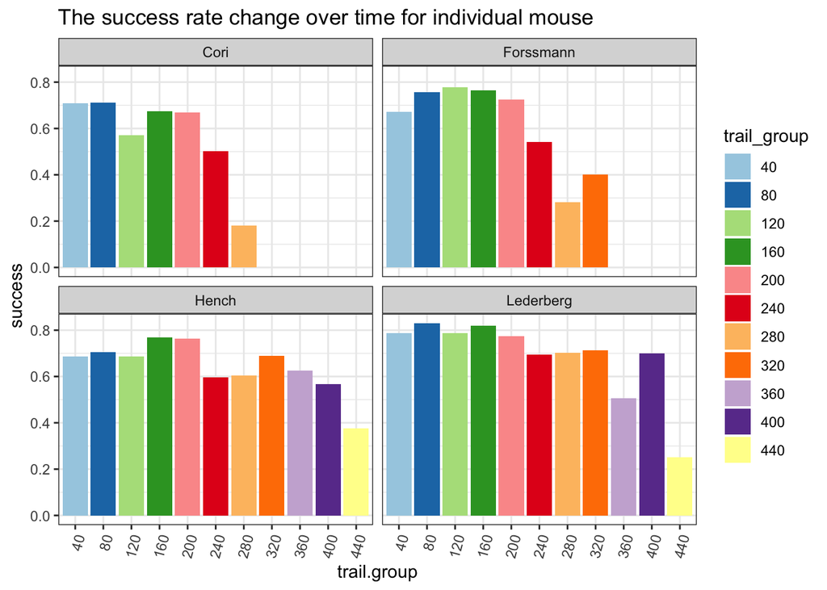

The graph shows a general decreasing in success rates across trial groups for each mouse. Initially, the success rates are stable, and remain in a decent success rate. However, after the middle of the trail_grouop around 200, the success rate begin to decrease. Cori and Forssmann have a shorter trail_group, which when their success trend start decreasing, it shows a quite sharp changes on the bar plot. Hench decrease with a more gradually changes, and it has the less obvious changes among all 4 mices. Lastly Lederberg shows the most variability in the success trend, it has the highest success rate in the first half of the trail group, but showing larger fluctuations in the trail group in the second half. Thes trend tend to highlight the importance of considering trial sequence, and fatigue factors of the mice in the anlysis.

### Visualize the change of overall spike rate cross different session and trail group

The change of overall neuron spike rate for each session

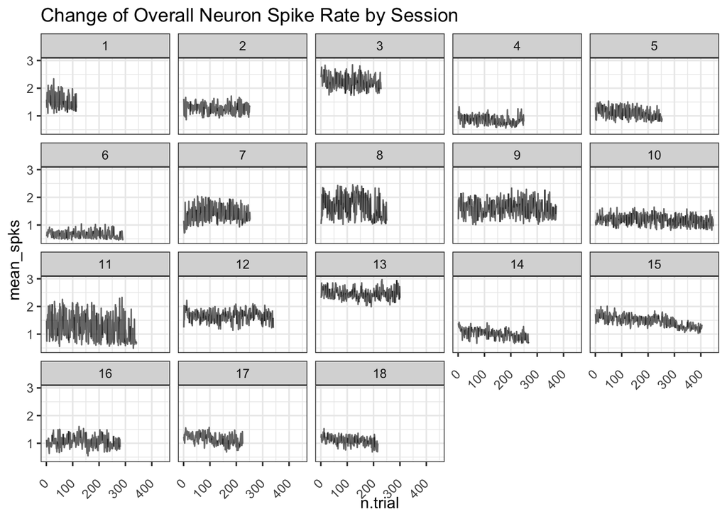

The change of overall neuron spike rate for each mouse

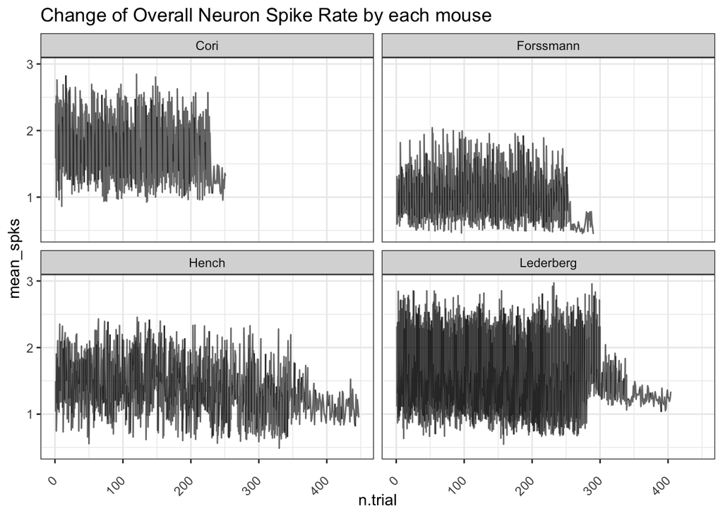

### Dimension Reduction through PCA

We perform PCA and visualize the 2D results.

```
## Importance of components:
##                           PC1    PC2    PC3    PC4    PC5     PC6     PC7
## Standard deviation     1.2967 1.1618 1.0625 1.0351 1.0111 0.87977 0.80457
## Proportion of Variance 0.2102 0.1687 0.1411 0.1339 0.1278 0.09675 0.08092
## Cumulative Proportion  0.2102 0.3789 0.5200 0.6540 0.7817 0.87850 0.95942
##                            PC8
## Standard deviation     0.56981
## Proportion of Variance 0.04058
## Cumulative Proportion  1.00000
```

The above summary table for the results from running a principal component analysis (PCA). The table provides the standard deviation, proportion of variance, and the cumulative of variance that is explained by the PC. The reason why we choose PC1 and PC2 to be our axis because if we use the remain pcs like PC3 and P4, the plot will not look as organized and distributed because the PC3,4 and others contains relatively smaller total variance.

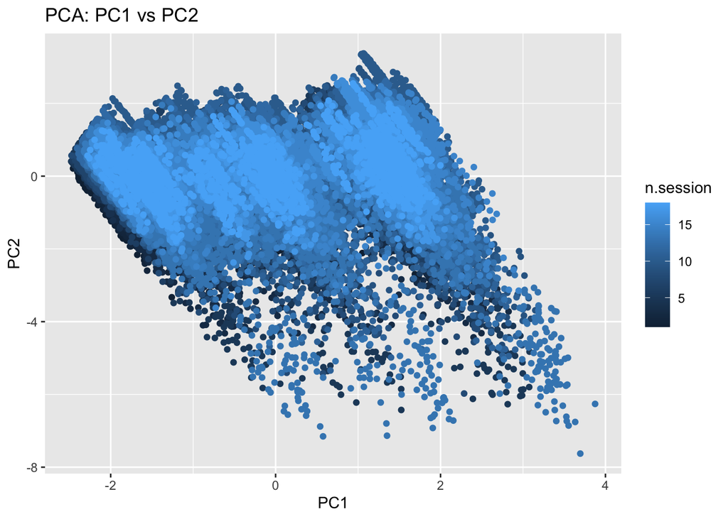

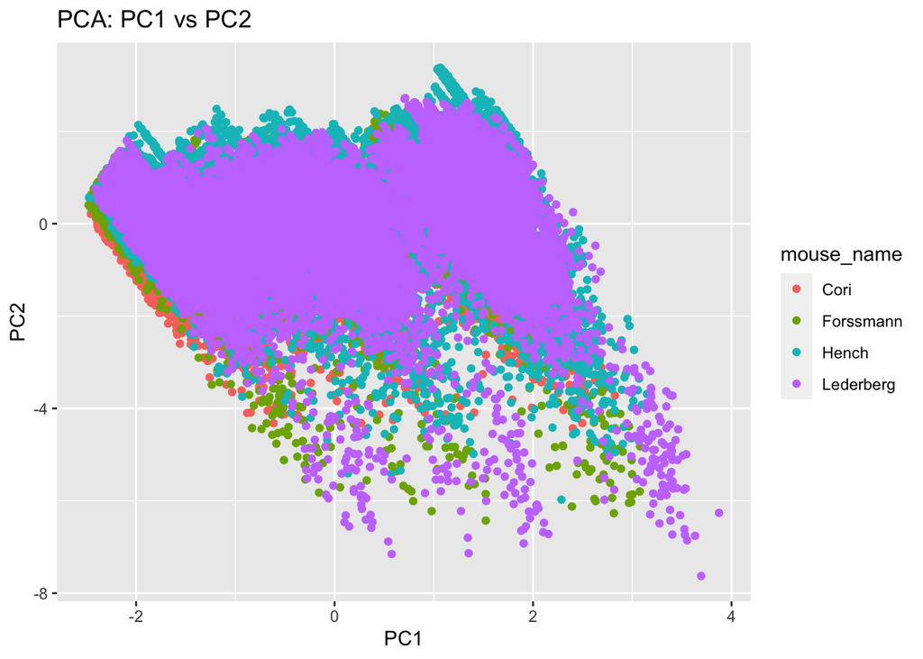

# Section 3 Data integration

```r
prediction_features <- c( "contrast_right", "contrast_left", "contrast_different", "sum_spks", "mean_spks")
head(full_tibble[prediction_features])
```

```
## # A tibble: 6 × 5
##   contrast_right contrast_left contrast_different sum_spks mean_spks
##            <dbl>         <dbl>              <dbl>    <dbl>     <dbl>
## 1            0.5             0                0.5      138     1.27
## 2            0.5             0                0.5      104     1.53
## 3            0.5             0                0.5       79     2.32
## 4            0.5             0                0.5      269     1.94
## 5            0.5             0                0.5      106     0.938
## 6            0.5             0                0.5      156     2.08
```

```r
predictive_dat <- full_tibble[prediction_features]

label <- as.numeric(full_tibble$success)
predictive_dat <- predictive_dat[!is.na(label),]
X <- model.matrix(~ ., predictive_dat)
X <- scale(X)
```

# Section 4 Predictive modeling

## Logistic regression Model

##Prediction results (accuracy, confusion matrix, AUROC)

```
##
## Call:
## glm(formula = train_label ~ ., family = binomial(link = "logit"),
##     data = train_df)
##
## Deviance Residuals:
##     Min       1Q   Median       3Q      Max
## -2.1545  -1.3978   0.7414   0.8832   1.3556
##
## Coefficients:
##                      Estimate Std. Error z value Pr(>|z|)
## (Intercept)         4.541e-01  2.330e-02  19.487  < 2e-16 ***
## contrast_right     -5.754e-01  3.424e-02 -16.803  < 2e-16 ***
## contrast_left      -2.885e-01  3.373e-02  -8.555  < 2e-16 ***
## contrast_different  1.224e+00  4.029e-02  30.383  < 2e-16 ***
## sum_spks            3.375e-04  9.293e-05   3.631 0.000282 ***
## mean_spks           1.117e-01  1.078e-02  10.368  < 2e-16 ***
## ---
## Signif. codes:  0 '***' 0.001 '**' 0.01 '*' 0.05 '.' 0.1 ' ' 1
##
## (Dispersion parameter for binomial family taken to be 1)
##
##     Null deviance: 47722  on 39338  degrees of freedom
## Residual deviance: 46508  on 39333  degrees of freedom
## AIC: 46520
##
## Number of Fisher Scoring iterations: 4
```

```r
predictions <- predict(logit_model, newdata = test_X_df)
predicted_labels <- as.numeric(ifelse(predictions > 0.5, 1, 0))
accuracy <- mean(predicted_labels == test_label)
accuracy
```

```
## [1] 0.5703681
```

```
##           Reference
## Prediction    0    1
##          0 1990 3286
##          1  939 3619
```

```
##
## Call:
## roc.default(response = test_label, predictor = predictions)
##
## Data: predictions in 2929 controls (test_label 0) < 6905 cases (test_label 1).
## Area under the curve: 0.6144
```

# Section 5 Prediction performance on the test sets

# Test prediction 1

### test the model’s performance on 50 random trails from session 18

```
##
## Call:
## glm(formula = train_label ~ ., family = binomial(link = "logit"),
##     data = train_df)
##
## Deviance Residuals:
##     Min       1Q   Median       3Q      Max
## -2.1713  -1.3928   0.7402   0.8840   1.3665
##
## Coefficients:
##                      Estimate Std. Error z value Pr(>|z|)
## (Intercept)         4.356e-01  2.085e-02  20.892  < 2e-16 ***
## contrast_right     -5.616e-01  3.055e-02 -18.379  < 2e-16 ***
## contrast_left      -3.082e-01  3.007e-02 -10.249  < 2e-16 ***
## contrast_different  1.241e+00  3.594e-02  34.537  < 2e-16 ***
## sum_spks            3.582e-04  8.324e-05   4.303 1.69e-05 ***
## mean_spks           1.172e-01  9.657e-03  12.133  < 2e-16 ***
## ---
## Signif. codes:  0 '***' 0.001 '**' 0.01 '*' 0.05 '.' 0.1 ' ' 1
##
## (Dispersion parameter for binomial family taken to be 1)
##
##     Null deviance: 59652  on 49122  degrees of freedom
## Residual deviance: 58076  on 49117  degrees of freedom
## AIC: 58088
##
## Number of Fisher Scoring iterations: 4
```

```
## [1] 0.68
```

```
##           Reference
## Prediction  0  1
##          0  6 14
##          1  2 28
```

```
##
## Call:
## roc.default(response = test_label, predictor = predicted_probabilities)
##
## Data: predicted_probabilities in 8 controls (test_label 0) < 42 cases (test_label 1).
## Area under the curve: 0.7679
```

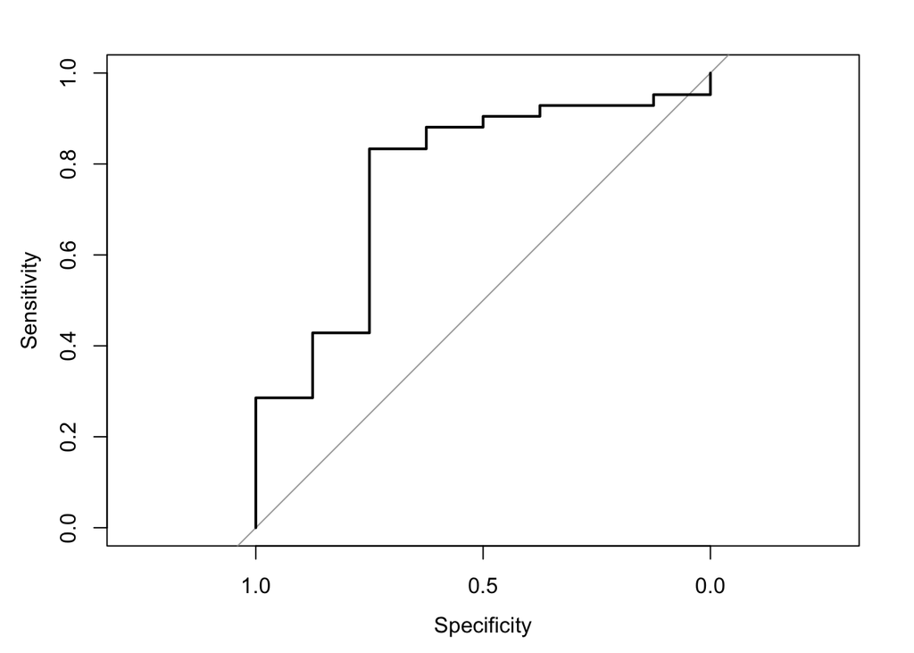

This model achieved an accuracy of 68% and an AUROC of 0.7679, indicating a strong ability to distinguish between classes. The confusion matrix shows a relatively balanced performance in predicting on both positive and negative classes, with more correct predictions for the positive class. This suggests good model performance in this specific session.

# Test prediction 2

### test the model’s performance on 50 random trails from session 1

```
##
## Call:
## glm(formula = train_label ~ ., family = binomial(link = "logit"),
##     data = train_df)
##
## Deviance Residuals:
##     Min       1Q   Median       3Q      Max
## -2.1711  -1.3929   0.7396   0.8834   1.3655
##
## Coefficients:
##                      Estimate Std. Error z value Pr(>|z|)
## (Intercept)         4.361e-01  2.085e-02  20.915  < 2e-16 ***
## contrast_right     -5.590e-01  3.056e-02 -18.292  < 2e-16 ***
## contrast_left      -3.092e-01  3.009e-02 -10.276  < 2e-16 ***
## contrast_different  1.242e+00  3.595e-02  34.562  < 2e-16 ***
## sum_spks            3.611e-04  8.331e-05   4.335 1.46e-05 ***
## mean_spks           1.170e-01  9.662e-03  12.109  < 2e-16 ***
## ---
## Signif. codes:  0 '***' 0.001 '**' 0.01 '*' 0.05 '.' 0.1 ' ' 1
##
## (Dispersion parameter for binomial family taken to be 1)
##
##     Null deviance: 59622  on 49122  degrees of freedom
## Residual deviance: 58045  on 49117  degrees of freedom
## AIC: 58057
##
## Number of Fisher Scoring iterations: 4
```

```
## [1] 0.5
```

```
##           Reference
## Prediction  0  1
##          0 11 11
##          1 14 14
```

```
##
## Call:
## roc.default(response = test_label, predictor = predicted_probabilities)
##
## Data: predicted_probabilities in 25 controls (test_label 0) < 25 cases (test_label 1).
## Area under the curve: 0.6272
```

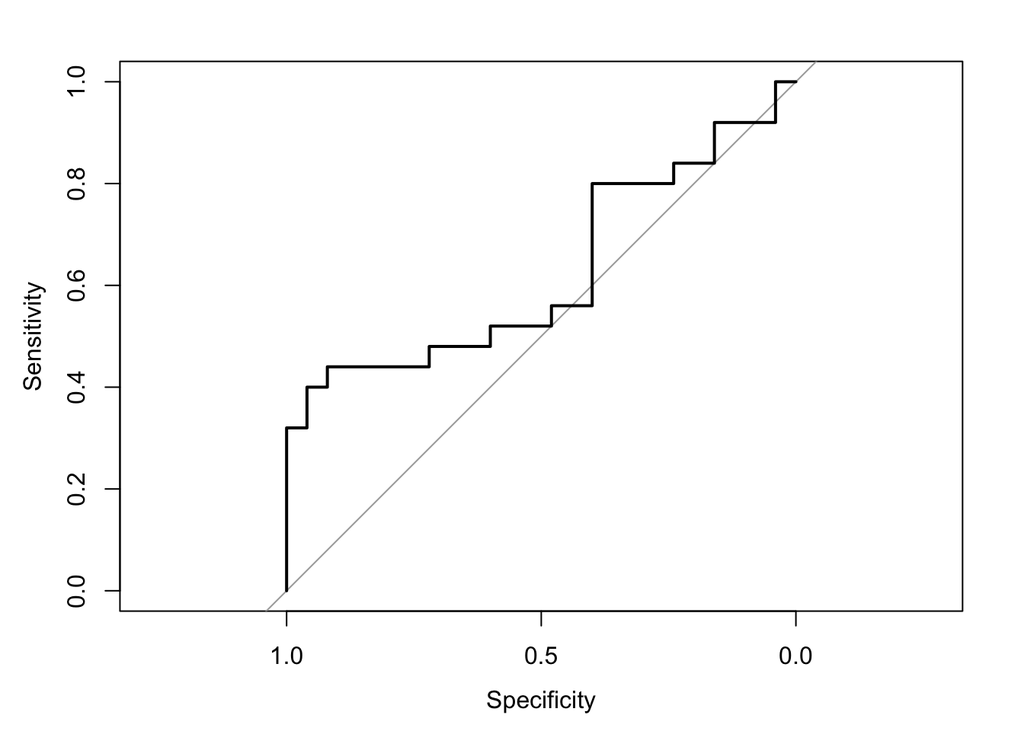

This test yielded an accuracy of 50% and an AUROC of 0.6272, demonstrating a moderate ability to differentiate between classes. The balanced confusion matrix indicates an equal number of correct and incorrect predictions across classes. The results suggest the model performance is not really well.

### Model testing with “test” data

```
## [1] 0.5
```

```
##           Reference
## Prediction  0  1
##          0 10 10
##          1 15 15
```

```
##
## Call:
## roc.default(response = test_label, predictor = test_predictions)
##
## Data: test_predictions in 25 controls (test_label 0) < 25 cases (test_label 1).
## Area under the curve: 0.6128
```

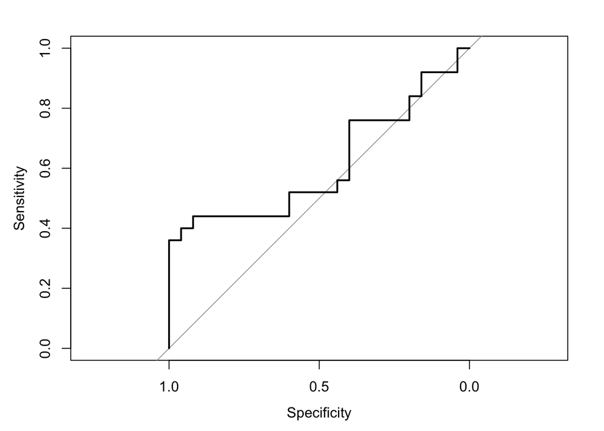

Summary results show an accuracy of 50% and an AUROC of 0.6128, indicating moderate class discrimination ability. Because the accuracy is so low, the confusion matrix reflects an equal split between correct and incorrect predictions, highlighting the limitations present in the model. Across the three tests, we observed variable performance of the logistic regression model, with the first test (Section 18) (accuracy = 0.68) giving the best results. Differences in model performance may be attributed to a variety of factors, including changes in data distribution, class differences, or specific characteristics of each set of data that affect the model’s predictive ability. However, through the latter two sets of predictions, we discovered the limitations of this model, which require further optimization to improve its prediction performance.

# Section 6 Discussions

In this project, we analyzed neural activity data from mice to predict experimental outcomes based on a variety of variables. The dataset consists of 18 sessions from four different mice and focuses on spike train data representing neuronal activity. We use R for data processing, exploratory analysis, and predictive modeling, combined with techniques such as data aggregation, PCA dimensionality reduction, and logistic regression for predictive modeling. Our exploratory analyzes revealed insights into neural activity, differences in brain regions engaged during trials, and differences in success rates across experiments and individual mice. We can observe significant differences in neural activity and success rates, suggesting differential differences in each mouse’s response to the trial. For predictive modeling, we used logistic regression, which was chosen for its ability to understand the impact of various predictors on the outcomes of different trials.. The model demonstrated moderate accuracy in predicting trial outcomes from different test prediction, although there were limitations in achieving high predictive performance across all sessions. In tests on separate data sets, the logistic regression model showed varying degrees of accuracy, suggesting that while it was less than ideal at predicting outcomes, there was still room for improvement. Factors such as data distribution, category characteristics, and data processing methods may affect model performance.

# Reference

chatgpt:https://chat.openai.com/ trail_data <- aggregate(cbind(sum_spks, region_count) ~ mouse_name + n.trail, data = full_tibble, sum) trail_data$mean_spks <- with(trail_data, sum_spks/region_count, sum) mouse_means_spks <- aggregate(mean_spks ~ mouse_name, data = trail_data, mean) names(mouse_means_spks)[names(mouse_means_spks) == “mean_spks”] <- “mean_mouse_spks” mouse_means_spks

prediction_features <- c(“n.session”, “n.trail”, “contrast_right”, “contrast_left”, “contrast_different”, “sum_spks”, “mean_spks”, “region_count”) head(full_tibble[predictive_feature]) predictive_dat <- full_tibble[prediction_features] predictive_dat <- na.omit(predictive_dat) predictive_dat$n.session <- as.numeric(as.factor(predictive_dat$n.session)) predictive_dat$n.trail <- as.numeric(as.factor(predictive_dat$n.trail)) label <- as.numeric(full_tibble$success) predictive_dat <- predictive_dat[!is.na(label),] label <- na.omit(label) X <- model.matrix(~ . - 1, predictive_dat) X <- scale(X)

logit_model <- glm(train_label ~ ., family = binomial(link = ‘logit’), data = train_df) summary(logit_model) predicted_probabilities <- predict(logit_model, type = “response”) # Get predicted probabilities predicted_classes <- ifelse(predicted_probabilities > 0.5, 1, 0) # Convert probabilities to class labels table(Predicted = predicted_classes, Actual = label) library(caret) confusionMatrix(factor(predicted_classes), factor(label)) library(pROC) roc_response <- roc(label, predicted_probabilities) auc(roc_response) plot(roc_response)

test_data <- list() for(i in 1:length(test)){ # Assuming ‘contrast_different’ and ‘mean_spks’ can be calculated or extracted similarly contrast_different <- abs(test[[i]]$contrast_left - test[[i]]$contrast_right) sum_spks <- sapply(test[[i]]$spks, function(x) sum(rowSums(x))) mean_spks <- sapply(test[[i]]$spks, function(x) mean(rowSums(x)))

test_data[[i]] <- data.frame( contrast_right = test[[i]]$contrast_right, contrast_left = test[[i]]$contrast_left, contrast_different = contrast_different, sum_spks = sum_spks, mean_spks = mean_spks ) }

I have used TA Jue Wang project demo as project guide for what each session I should do. file:///Users/xiepengwanru/Downloads/Course_project_demo.html file:///Users/xiepengwanru/Downloads/Lab7-3.html Steinmetz, N.A., Zatka-Haas, P., Carandini, M. et al. Distributed coding of choice, action and engagement across the mouse brain. Nature 576, 266–273 (2019). https://doi.org/10.1038/s41586-019-1787-x